# 傳統信仰新概念 「拜拜減碳 神明稱讚」

B02607022 農經系簡士鈞 & B02607055 農經系許家瑜

2017/6/14

## 傳統信仰新概念 「拜拜減碳 神明稱讚」

台劇《通靈少女》躍上HBO，在23個國家同步上映，劇中主角謝雅真白天是戲劇社高中生，和轉學生同學擦出火花，晚上則在公廟當神明與信眾之間的譯者，特殊的故事題材、背景以及角色設定，讓傳統信仰隨著這股熱潮重新被認識，引起討論的除了劇情，民俗活動的設定也讓觀眾「耳目一新」。 劇中議員收到釘有自己名字的稻草小人，而到宮廟尋找幫助，一切以「客戶至上」的宮廟經營者金老師馬上說要拜三牲四果、斬雞頭，再做一個紙人，燒它化解。而小真馬上反應：「你們大人很奇怪，那麼殘忍為什麼一定要殺雞？」金老師回說這是規矩，而所謂的規矩其實就是傳統。 此外，小男孩小凱因為雙親失和，習慣以假裝中邪來博取關注，有一天卻真的被附身，小珍幫忙化解了以後，將符燒進水中，要小凱輕輕抿一下小心別喝到。傳統習俗中舉凡生病、遭到厄運，都有符水的習慣，今年國中會考滿級分作文也有同學寫到，從喝符水這個傳統活動看見媽媽的愛，但將燃燒過後的灰燼浸入水中服用，有悖於現代衛生健康安全，衛生署也呼籲過民眾為避免重金屬中毒，別服用符水。

[interactive chart not shown]

行天宮實施禁香措施是從2014年8月開始，上圖為禁香前一年與禁香後同月份的PM2.5濃度比較圖，從2014年8月後的濃度變化可看出整體較前年濃度降低許多，可知禁香後對於當地空氣品質改善發揮顯著效果，這是支持禁香的廟宇信徒樂於見到的結果，也是環保署近年來積極呼籲禁燒金燒香所期望達到的成果。

而社會聲浪除了質疑是否有成效，也批評行天宮不重視傳統文化，突然公告禁香，會造成香客流失。

對此行天宮執事李楚華表示，禁香的想法其實源自於建廟時就有用「心香」敬神的觀念，神明都是道德最高的，不需要民間用有形物去供奉，因此幾十年來也秉持不燒金紙的原則。民國八十七年，消基會抽驗宮內爐丹，發現含有重金屬物質，原本對於廟方以及信眾來說，爐丹是純淨且經過恩主公加持，因此許多人習慣帶上一把回家保平安。行天宮遂尋找問題的原因，發現因為外頭攤販多，儘管有經濟部標準檢驗局公布的香品資料，還是無法控管空品來源，於是昭告攤販五年內一定會減香，也開始對信眾宣導。民國九十二年，香爐從五爐減成兩爐，拜桌從二十七張減成十五張，也持續訂下十年內會禁香及禁供。從民國九十二年至一百零三年，十年多的時間應足夠攤販調整經營重心，也將減碳的觀念植入信眾心中。因此，社會輿論認為行天宮「無預警」禁香，這個說法是有待改正的。 且禁香後，行天宮內媒體所拍攝的照片相對禁香前冷清許多，對此行天宮表示香客並無減少 ! 可能原因也許與民眾習慣香插進香爐後再坐一下以表示誠心，少掉半炷香的時間，香客停留時間減少了，流動性自然提高，且原先十五張拜桌撤除後，場地視覺上也變空曠了。

儘管行天宮表示並無拋磚引玉的意思，但各廟在如此重大的改變下也遭受壓力，台北市龍山寺廟方與周邊攤販表示目前新聞報導將跟進禁香實屬流傳，官方發言人並未有明確說明，因此是否比照行天宮以手代香進行拜拜祭祀仍未確定。 但實地走訪龍山寺，香客對於禁香多持正向態度，表示不使用香能有效降低空氣污染且不會因為以手合十祭拜改變了傳統拿香習俗而不再去參拜，「畢竟心誠則靈嘛」，一位經常到訪的信徒如是說。 可知龍山寺如果想要跟進禁香模式，雖必定會引起部分群眾反彈，但仍有一定數量香客接受改變傳統習俗以利附近空氣品質改善，長遠眼光來看，廟宇改變拿香燒金紙習俗改以不造成廢氣產生方式祭祀必定有利於空氣品質改善以及附近居民的健康，也許環保署倡導的減少空汙排放相關政策已勢在必行，端看廟方該如何善用方法讓香客們不再拘泥於傳統祭拜習俗，相信信仰源於心，心誠則靈驗的道理。

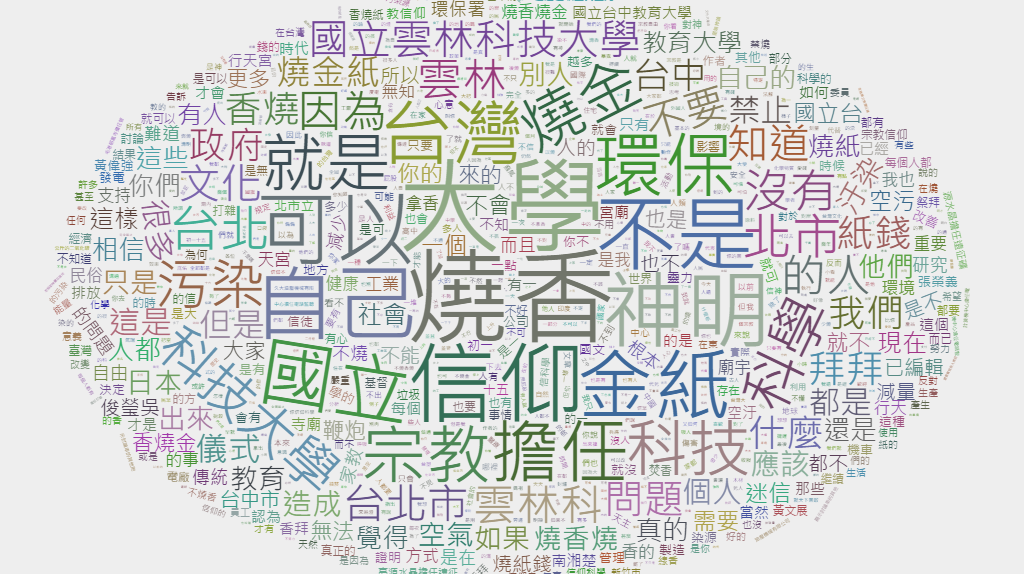

一般民眾會到廟宇，也會在家祭祀，因此政府推動線上拜拜以落實環保，根據SimilarWeb網站流量分析，北市政府於2015年設置的「拜拜減碳 神明稱讚」網頁每月份平均瀏覽人數少於5000人，可見並不屬於熱門網站，而進入網站的訪客平均瀏覽時間約1分15秒，每次瀏覽1.75個頁面，但造訪此網站只瀏覽一個頁面便離開的比例將近8成，可見多數人對於網站內容並沒有興趣無法引發共鳴而想停留了解網站內容。其中，有84%的訪客是透過搜尋引擎進入網站，搜尋的關鍵字包括網路普渡 、環保紙錢、減燒⾦紙、電⼦⾹、燒⾦紙等， 關鍵字與傳統燒香方式牽涉到的環保議題有關，可知進入瀏覽的人關心傳統習俗造成空汙議題，但由瀏覽人數與停留時間可知也許關心的人仍為少數，且網站內容目前僅就普渡服務未能切合大眾常年需求。

[interactive chart not shown]

對於空氣汙染來說，寺廟及居家燒香造成的細懸浮粒子，當然不及於工業排放，但卻是民眾會近身接觸的，從健康的角度出發，減量的確有助於促進人體暴露在空氣污染之下，且就像行天宮秉持勿以善小而不為的態度，從一般民眾開始做起，微小的力量帶起的觀念也許能讓社會更多人投入減少空氣汙染的各項運動。

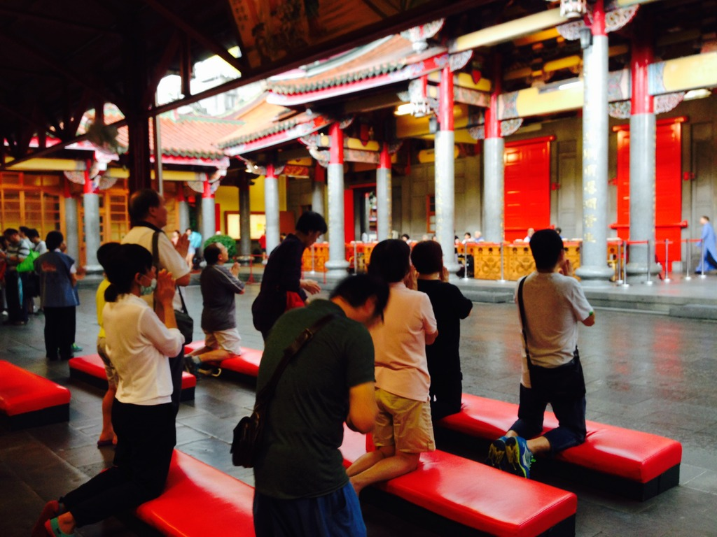

＊註1 龍世俊，香客在寺廟中懸浮微粒曝露濃度之探討，2000。《中華公共衛生雜誌》，19-2 ， P138 - 143